# shopping_total

```python
import pandas as pd
import os
import matplotlib.pyplot as plt
from matplotlib import font_manager as fm, rc

font_path = './Fonts/malgun.ttf'
font_name = fm.FontProperties(fname = font_path).get_name()
rc('font', family = font_name)

plt.rc('font', size=20)        # 기본 폰트 크기
plt.rc('axes', labelsize=20)   # x,y축 label 폰트 크기
plt.rc('xtick', labelsize=16)  # x축 눈금 폰트 크기
plt.rc('ytick', labelsize=20)  # y축 눈금 폰트 크기
plt.rc('legend', fontsize=12)  # 범례 폰트 크기
plt.rc('figure', titlesize=40) # figure title 폰트 크기
```

### 분석과정

- 1차적으로 네이버 쇼핑의 클릭수 분석을 통해 지난 1년간 클릭수가 유의한 변동을 보인 분야를 탐색
- 2차적으로 가장 변동이 크다고 생각된 도서 분야에서 실제 판매 내역과 클릭수정보의 비교

```
- 1차, 2차 과정에서 각 조원별로 분류를 나누어 분석을 진행 하였습니다.
- ex) 정한수 : 1차 과정 - 패션과 화장품,  2차 과정 - 컴퓨터_정보기술 도서
```

### 네이버 자료 대분류별 자료 통합 분석

```
- 자료출처 : 네이버 데이터 랩 (https://datalab.naver.com/)
- 조원별로 각 분야의 성별, 나이대별 자료를 통합하고 일정한 형식을 가진 데이터 프레임으로 변환
```

```python
TOTAL_PATH = './naver_shopping/'
os.listdir(TOTAL_PATH)
```

```
['가구_인테리어.csv',
 '도서.csv',
 '디지털_가전.csv',
 '생활건강.csv',
 '스포츠레저.csv',
 '식품.csv',
 '여가_생활편의.csv',
 '패션의류.csv',
 '패션잡화.csv',
 '화장품_미용.csv']
```

```python
total_datas = [pd.read_csv(TOTAL_PATH + f, index_col= 0 ) for f in os.listdir(TOTAL_PATH)]
total_data_names = [f.split('.')[0] for f in os.listdir(TOTAL_PATH)]
```

```python
total_datas[0]
```

| 날짜 | 남자10대 | 남자20대 | 남자30대 | 남자40대 | 남자50대 | 남자60대 | 여자10대 | 여자20대 | 여자30대 | 여자40대 | 여자50대 | 여자60대 |
| --- | --- | --- | --- | --- | --- | --- | --- | --- | --- | --- | --- | --- |
| 2021-07-09 | 48 | 62 | 59 | 51 | 53 | 59 | 49 | 65 | 57 | 50 | 49 | 54 |
| 2021-07-10 | 65 | 65 | 66 | 58 | 59 | 62 | 70 | 71 | 65 | 60 | 60 | 61 |
| 2021-07-11 | 79 | 81 | 85 | 71 | 68 | 68 | 78 | 88 | 82 | 74 | 68 | 66 |
| 2021-07-12 | 63 | 84 | 85 | 70 | 67 | 68 | 62 | 86 | 78 | 66 | 58 | 61 |
| 2021-07-13 | 58 | 83 | 79 | 66 | 64 | 67 | 58 | 82 | 75 | 64 | 58 | 62 |
| ... | ... | ... | ... | ... | ... | ... | ... | ... | ... | ... | ... | ... |
| 2022-07-05 | 39 | 74 | 71 | 63 | 69 | 79 | 34 | 62 | 57 | 54 | 59 | 71 |
| 2022-07-06 | 40 | 73 | 68 | 61 | 67 | 77 | 34 | 60 | 56 | 53 | 58 | 69 |
| 2022-07-07 | 37 | 70 | 65 | 57 | 64 | 74 | 35 | 57 | 53 | 50 | 56 | 66 |
| 2022-07-08 | 35 | 64 | 57 | 51 | 57 | 71 | 34 | 52 | 46 | 45 | 51 | 62 |
| 2022-07-09 | 44 | 62 | 57 | 51 | 58 | 68 | 41 | 51 | 47 | 47 | 56 | 66 |

366 rows × 12 columns

```python
for data in total_datas:
    print(data.columns)
```

```
Index(['남자10대', '남자20대', '남자30대', '남자40대', '남자50대', '남자60대', '여자10대', '여자20대',
       '여자30대', '여자40대', '여자50대', '여자60대'],
      dtype='object')
Index(['도서_남자_10', '도서_남자_20', '도서_남자_30', '도서_남자_40', '도서_남자_50', '도서_남자_60',
       '도서_여자_10', '도서_여자_20', '도서_여자_30', '도서_여자_40', '도서_여자_50', '도서_여자_60'],
      dtype='object')
Index(['남자10대', '남자20대', '남자30대', '남자40대', '남자50대', '남자60대', '여자10대', '여자20대',
       '여자30대', '여자40대', '여자50대', '여자60대'],
      dtype='object')
Index(['생활건강_남성_10대', '생활건강_남성_20대', '생활건강_남성_30대', '생활건강_남성_40대',
       '생활건강_남성_50대', '생활건강_남성_60대', '생활건강_여성_10대', '생활건강_여성_20대',
       '생활건강_여성_30대', '생활건강_여성_40대', '생활건강_여성_50대', '생활건강_여성_60대'],
      dtype='object')
Index(['스포츠레저_남성_10대', '스포츠레저_남성_20대', '스포츠레저_남성_30대', '스포츠레저_남성_40대',
       '스포츠레저_남성_50대', '스포츠레저_남성_60대', '스포츠레저_여성_10대', '스포츠레저_여성_20대',
       '스포츠레저_여성_30대', '스포츠레저_여성_40대', '스포츠레저_여성_50대', '스포츠레저_여성_60대'],
      dtype='object')
Index(['남자10대', '남자20대', '남자30대', '남자40대', '남자50대', '남자60대', '여자10대', '여자20대',
       '여자30대', '여자40대', '여자50대', '여자60대'],
      dtype='object')
Index(['여가_생활편의_남자_10', '여가_생활편의_남자_20', '여가_생활편의_남자_30', '여가_생활편의_남자_40',
       '여가_생활편의_남자_50', '여가_생활편의_남자_60', '여가_생활편의_여자_10', '여가_생활편의_여자_20',
       '여가_생활편의_여자_30', '여가_생활편의_여자_40', '여가_생활편의_여자_50', '여가_생활편의_여자_60'],
      dtype='object')
Index(['여성_60대_이상', '여성_50대', '여성_40대', '여성_30대', '여성_20대', '여성_10대',
       '남성_60대_이상', '남성_50대', '남성_40대', '남성_30대', '남성_20대', '남성_10대'],
      dtype='object')
Index(['여성_60대_이상', '여성_50대', '여성_40대', '여성_30대', '여성_20대', '여성_10대',
       '남성_60대_이상', '남성_50대', '남성_40대', '남성_30대', '남성_20대', '남성_10대'],
      dtype='object')
Index(['여성_60대_이상', '여성_50대', '여성_40대', '여성_30대', '여성_20대', '여성_10대',
       '남성_60대_이상', '남성_50대', '남성_40대', '남성_30대', '남성_20대', '남성_10대'],
      dtype='object')
```

```python
for i in range(len(total_datas)):
    print(total_data_names[i],' :\n',total_datas[i].index[[0,-1]], '\n')
```

```
가구_인테리어  :
 Index(['2021-07-09', '2022-07-09'], dtype='object', name='날짜')

도서  :
 Index(['2021-07-09', '2022-07-09'], dtype='object', name='날짜')

디지털_가전  :
 Index(['2021-07-09', '2022-07-09'], dtype='object', name='날짜')

생활건강  :
 Index(['2021-07-09', '2022-07-09'], dtype='object', name='날짜')

스포츠레저  :
 Index(['2021-07-09', '2022-07-09'], dtype='object', name='날짜')

식품  :
 Index(['2021-07-09', '2022-07-09'], dtype='object', name='날짜')

여가_생활편의  :
 Index(['2021-07-09', '2022-07-09'], dtype='object', name='날짜')

패션의류  :
 Index(['2021-07-09', '2022-07-09'], dtype='object', name='날짜')

패션잡화  :
 Index(['2021-07-09', '2022-07-09'], dtype='object', name='날짜')

화장품_미용  :
 Index(['2021-07-09', '2022-07-09'], dtype='object', name='날짜')
```

```python
total_total = pd.concat([data.apply(sum, axis = 1) for data in total_datas], axis = 1)
total_total.columns = total_data_names

total_total
```

| 날짜 | 가구_인테리어 | 도서 | 디지털_가전 | 생활건강 | 스포츠레저 | 식품 | 여가_생활편의 | 패션의류 | 패션잡화 | 화장품_미용 |
| --- | --- | --- | --- | --- | --- | --- | --- | --- | --- | --- |
| 2021-07-09 | 656 | 337 | 755 | 700 | 561 | 566 | 490 | 445 | 527 | 129 |
| 2021-07-10 | 762 | 331 | 835 | 723 | 639 | 570 | 521 | 524 | 611 | 143 |
| 2021-07-11 | 908 | 376 | 966 | 824 | 770 | 667 | 544 | 615 | 692 | 169 |
| 2021-07-12 | 848 | 430 | 1016 | 852 | 743 | 739 | 536 | 551 | 598 | 162 |
| 2021-07-13 | 816 | 420 | 1031 | 818 | 725 | 737 | 538 | 564 | 588 | 163 |
| ... | ... | ... | ... | ... | ... | ... | ... | ... | ... | ... |
| 2022-07-05 | 732 | 512 | 939 | 813 | 847 | 830 | 940 | 629 | 627 | 184 |
| 2022-07-06 | 716 | 509 | 925 | 803 | 814 | 807 | 918 | 624 | 615 | 182 |
| 2022-07-07 | 684 | 486 | 892 | 771 | 762 | 791 | 880 | 590 | 580 | 174 |
| 2022-07-08 | 625 | 227 | 791 | 703 | 672 | 691 | 846 | 526 | 531 | 151 |
| 2022-07-09 | 648 | 40 | 785 | 685 | 723 | 657 | 874 | 583 | 593 | 157 |

366 rows × 10 columns

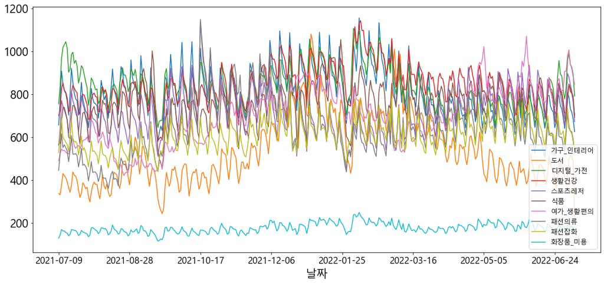

```python
fig = plt.figure(figsize=(18, 8))
ax = plt.subplot(1,1,1)
total_total.iloc[:-1].plot(ax = ax)
```

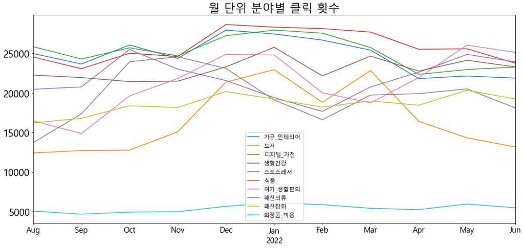

```python
total_total.index = pd.to_datetime(total_total.index)
total_month_datas = total_total.to_period('m').reset_index().groupby('날짜').sum()


fig = plt.figure(figsize=(18, 8))
ax = plt.subplot(1,1,1)
total_month_datas.loc['2021-08': '2022-06'].plot(ax = ax)

plt.title('월 단위 분야별 클릭 횟수')
plt.xlabel('')
```

- 화장품이 가장 낮은 클릭수를 보인다.
- 도서분야가 변동이 크다고 판단
- 도서 분야에서 특정 월만 높은 관심도를 보이는데 이를 자세히 알아보고 해결 방안을 찾아보기

```python
def min_max(data):
    data_max, data_min = data.max(), data.min()
    return (data-data_min)/(data_max - data_min)

total_month_datas.apply(min_max)
```

| 날짜 | 가구_인테리어 | 도서 | 디지털_가전 | 생활건강 | 스포츠레저 | 식품 | 여가_생활편의 | 패션의류 | 패션잡화 | 화장품_미용 |
| --- | --- | --- | --- | --- | --- | --- | --- | --- | --- | --- |
| 2021-07 | 0.530122 | 0.260892 | 0.653572 | 0.499610 | 0.488029 | 0.447092 | 0.255398 | 0.325489 | 0.507674 | 0.432164 |
| 2021-08 | 0.862761 | 0.458104 | 0.895309 | 0.811500 | 0.728206 | 0.815189 | 0.461257 | 0.432538 | 0.720776 | 0.771013 |
| 2021-09 | 0.801777 | 0.473535 | 0.817837 | 0.743500 | 0.744312 | 0.798727 | 0.371795 | 0.622477 | 0.760057 | 0.684536 |
| 2021-10 | 0.912826 | 0.476570 | 0.888180 | 0.833280 | 1.000000 | 0.771800 | 0.639058 | 0.966635 | 0.866946 | 0.741672 |
| 2021-11 | 0.834351 | 0.596111 | 0.837928 | 0.814801 | 0.865914 | 0.774745 | 0.763102 | 1.000000 | 0.851869 | 0.752702 |
| 2021-12 | 1.000000 | 0.919706 | 0.964555 | 1.000000 | 0.787764 | 0.869833 | 0.934660 | 0.922759 | 0.988709 | 0.902713 |
| 2022-01 | 0.977512 | 1.000000 | 1.000000 | 0.984639 | 0.671026 | 1.000000 | 0.929993 | 0.713994 | 0.924481 | 1.000000 |
| 2022-02 | 0.941560 | 0.787871 | 0.980807 | 0.976386 | 0.576609 | 0.809824 | 0.661437 | 0.583882 | 0.855723 | 0.950805 |
| 2022-03 | 0.882982 | 0.994033 | 0.889925 | 0.956119 | 0.744150 | 0.941306 | 0.589575 | 0.746784 | 0.908593 | 0.847562 |
| 2022-04 | 0.716593 | 0.664163 | 0.721222 | 0.856481 | 0.844944 | 0.841590 | 0.769512 | 0.756197 | 0.872220 | 0.810942 |
| 2022-05 | 0.731584 | 0.556607 | 0.751383 | 0.859141 | 0.966438 | 0.913537 | 1.000000 | 0.787575 | 1.000000 | 0.967351 |
| 2022-06 | 0.719184 | 0.497094 | 0.766938 | 0.775964 | 0.915743 | 0.869938 | 0.948493 | 0.661855 | 0.925563 | 0.862343 |
| 2022-07 | 0.000000 | 0.000000 | 0.000000 | 0.000000 | 0.000000 | 0.000000 | 0.000000 | 0.000000 | 0.000000 | 0.000000 |

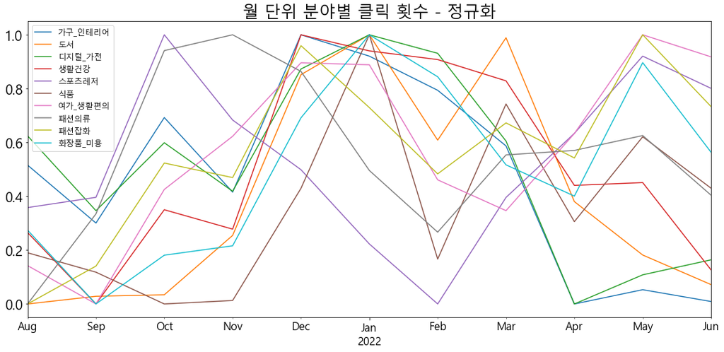

```python
fig = plt.figure(figsize=(18, 8))
ax = plt.subplot(1,1,1)
total_month_datas.loc['2021-08': '2022-06'].apply(min_max).plot(ax = ax)

plt.title('월 단위 분야별 클릭 횟수 - 정규화')
plt.xlabel('')
```

### 도서 분야별 네이버 자료 비교

- 도서분야에 대해 2차적인 분석 실시

  ```
    - 도서분야 자료내의 중분류들에 대해서도 대분류에서의 과정과 마찬가지로
    - 조원들이 나누어서 자료를 만들고 통합하여 전체 자료를 생성
  ```

```python
TOTAL_BOOK_PATH = './book_naver/'
os.listdir(TOTAL_PATH)


total_books = [pd.read_csv(TOTAL_BOOK_PATH + f, index_col= 0 ) for f in os.listdir(TOTAL_BOOK_PATH)]
total_book_names = [f.split('.')[0] for f in os.listdir(TOTAL_BOOK_PATH)]


total_total_books = pd.concat([data.apply(sum, axis = 1) for data in total_books], axis = 1)
total_total_books.columns = total_book_names

total_total_books
```

| 날짜 | 건강 | 경제_경영 | 생활취미레저 | 소설 | 자기계발 | 컴퓨터_IT |
| --- | --- | --- | --- | --- | --- | --- |
| 2021-07-09 | 270 | 183 | 283 | 288 | 110 | 163 |
| 2021-07-10 | 242 | 190 | 297 | 293 | 83 | 126 |
| 2021-07-11 | 311 | 238 | 346 | 330 | 90 | 155 |
| 2021-07-12 | 382 | 307 | 361 | 314 | 101 | 183 |
| 2021-07-13 | 357 | 282 | 366 | 342 | 104 | 172 |
| ... | ... | ... | ... | ... | ... | ... |
| 2022-07-05 | 475 | 201 | 523 | 327 | 132 | 310 |
| 2022-07-06 | 499 | 195 | 574 | 301 | 127 | 243 |
| 2022-07-07 | 409 | 200 | 509 | 312 | 116 | 269 |
| 2022-07-08 | 202 | 130 | 302 | 174 | 49 | 106 |
| 2022-07-09 | 37 | 14 | 35 | 32 | 1 | 9 |

366 rows × 6 columns

```python
for i in range(len(total_books)):
    print(total_book_names[i],' :\n',total_books[i].index[[0,-1]], '\n')
```

```
건강  :
 Index(['2021-07-09', '2022-07-09'], dtype='object', name='날짜')

경제_경영  :
 Index(['2021-07-09', '2022-07-09'], dtype='object', name='날짜')

생활취미레저  :
 Index(['2021-07-09', '2022-07-09'], dtype='object', name='날짜')

소설  :
 Index(['2021-07-09', '2022-07-09'], dtype='object', name='날짜')

자기계발  :
 Index(['2021-07-09', '2022-07-09'], dtype='object', name='날짜')

컴퓨터_IT  :
 Index(['2021-07-09', '2022-07-09'], dtype='object', name='날짜')
```

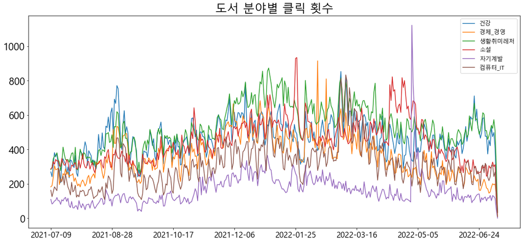

```python
fig = plt.figure(figsize=(18, 8))
ax = plt.subplot(1,1,1)
total_total_books.plot(ax = ax)

plt.title('도서 분야별 클릭 횟수')
plt.xlabel('')
```

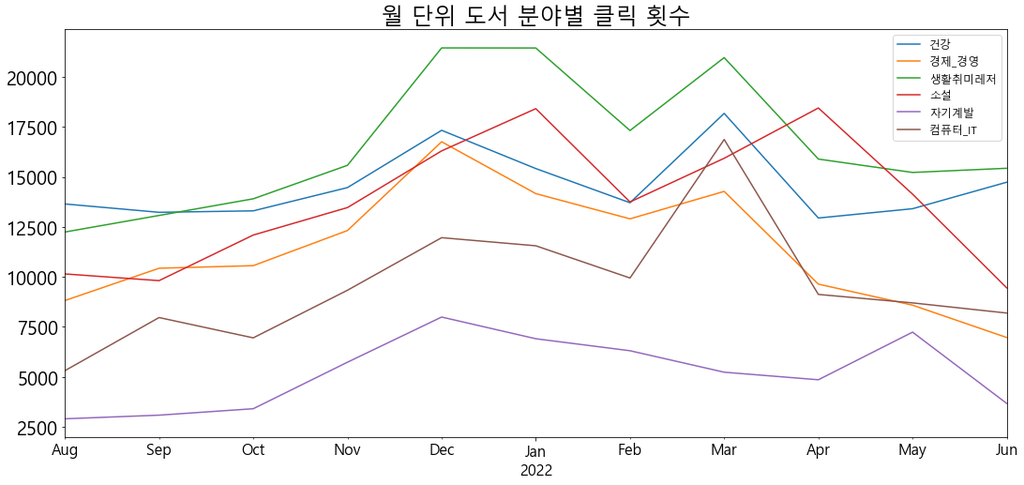

```python
total_total_books.index = pd.to_datetime(total_total_books.index)
total_month_books = total_total_books.to_period('m').reset_index().groupby('날짜').sum()


fig = plt.figure(figsize=(18, 8))
ax = plt.subplot(1,1,1)
total_month_books.loc['2021-08': '2022-06'].plot(ax = ax)

plt.title('월 단위 도서 분야별 클릭 횟수')
plt.xlabel('')
```

대부분 12월, 3월에 많은 증가량을 보임.  
이는 년이 바뀌는 시기와 개학, 개강시즌에 의한 영향으로 판단 하였습니다.

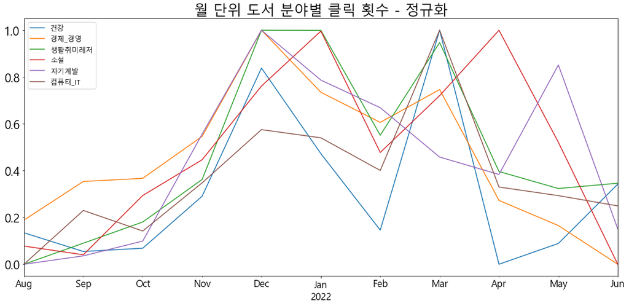

```python
fig = plt.figure(figsize=(18, 8))
ax = plt.subplot(1,1,1)
total_month_books.loc['2021-08': '2022-06'].apply(min_max).plot(ax = ax)
plt.title('월 단위 도서 분야별 클릭 횟수 - 정규화')
plt.xlabel('')
```

##### 출판 유통 통합 유통망 내 전체 자료 분석

```
- 실제 판매 기록을 통해 네이버 쇼핑에서의 클릭수가 실제 고객의 관심사를 반영하는지 확인
- 자료출처 : https://bnk.kpipa.or.kr/home/v3/addition/adiStatsCtgSaleCnt
```

```python
total_report = pd.read_csv('./book/총합_판매_보고서.csv', header = 2, index_col=0)
total_report.columns = total_report.columns.str.replace('.1', '_온라인')
total_report.columns = total_report.columns.str.replace('.2', '_지역서점')
total_report.rename(columns = {'부수' : '부수_오프라인', '종수' : '종수_오프라인','금액' : '금액_오프라인'}, inplace = True)
total_report
```

|  | 부수_오프라인 | 종수_오프라인 | 금액_오프라인 | 부수_온라인 | 종수_온라인 | 금액_온라인 | 부수_지역서점 | 종수_지역서점 | 금액_지역서점 |
| --- | --- | --- | --- | --- | --- | --- | --- | --- | --- |
| 21년 07월 | 2,887,272 | 190,783 | 37,924,299,264 | 2,129,435 | 196,782 | 31,061,158,200 | 26,493 | 6,545 | 342,811,545 |
| 21년 08월 | 2,813,282 | 187,248 | 37,309,466,590 | 1,917,613 | 192,817 | 28,521,508,973 | 110,370 | 24,601 | 1,202,992,750 |
| 21년 09월 | 4,967,348 | 259,138 | 70,442,223,108 | 3,900,729 | 239,888 | 58,023,291,440 | 127,830 | 32,174 | 1,577,210,057 |
| 21년 10월 | 3,784,268 | 250,465 | 52,115,206,320 | 3,130,552 | 212,364 | 44,487,635,963 | 114,897 | 33,681 | 1,425,679,905 |
| 21년 11월 | 4,387,361 | 264,495 | 61,131,519,170 | 3,801,893 | 237,705 | 54,465,465,220 | 310,860 | 52,079 | 3,856,620,454 |
| 21년 12월 | 4,966,845 | 262,982 | 69,977,107,300 | 5,038,612 | 244,695 | 69,575,764,507 | 447,322 | 59,316 | 5,584,279,516 |
| 22년 01월 | 4,610,378 | 244,889 | 66,845,937,638 | 4,307,469 | 231,664 | 61,932,680,351 | 488,445 | 52,601 | 5,860,489,073 |
| 22년 02월 | 4,514,831 | 253,006 | 63,619,036,877 | 3,970,439 | 234,505 | 55,823,029,282 | 383,882 | 50,789 | 4,533,934,259 |
| 22년 03월 | 5,544,083 | 271,401 | 82,739,160,471 | 4,827,234 | 253,608 | 71,798,648,439 | 500,858 | 49,806 | 5,605,809,742 |
| 22년 04월 | 4,544,766 | 265,711 | 64,173,609,495 | 3,991,207 | 241,990 | 56,601,614,080 | 344,873 | 49,058 | 4,309,909,323 |
| 22년 05월 | 4,332,877 | 261,151 | 59,911,046,813 | 3,599,570 | 236,351 | 51,124,749,599 | 300,495 | 50,747 | 3,697,133,366 |
| 22년 06월 | 3,360,727 | 234,734 | 47,402,041,761 | 6,392,236 | 230,390 | 86,790,851,731 | 290,792 | 48,722 | 3,612,839,250 |

```python
total_report.replace(',', '', regex=True, inplace = True)
total_report = total_report.astype(float)
total_report.dtypes
```

```
부수_오프라인    float64
종수_오프라인    float64
금액_오프라인    float64
부수_온라인     float64
종수_온라인     float64
금액_온라인     float64
부수_지역서점    float64
종수_지역서점    float64
금액_지역서점    float64
dtype: object
```

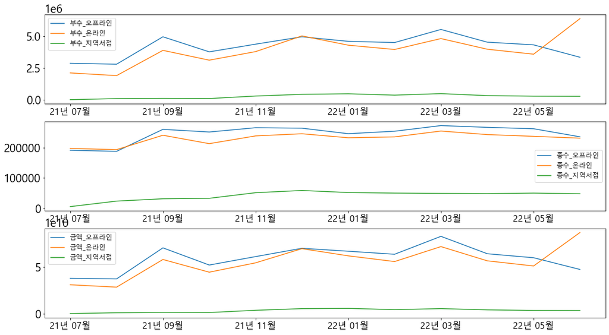

```python
fig = plt.figure(figsize=(18, 10))
ax = plt.subplot(3,1,1)
total_report.filter(like = '부수').plot(ax = ax)
ax = plt.subplot(3,1,2)
total_report.filter(like = '종수').plot(ax = ax)
ax = plt.subplot(3,1,3)
total_report.filter(like = '금액').plot(ax = ax)
```

9월, 12월, 3월에 판매 부수와 판매 금액이 증가

### 네이버 쇼핑 클릭 수와 실재 판매 판수 간의 관계 분석

```python
for col in ['부수','금액']:
    total_report[col + '_total'] = total_report.filter(like = col).apply(sum, axis = 1)

total_report_total = total_report[total_report.columns[-2:]].copy()[1:]
total_report_total
```

|  | 부수_total | 금액_total |
| --- | --- | --- |
| 21년 08월 | 4841265.0 | 6.703397e+10 |
| 21년 09월 | 8995907.0 | 1.300427e+11 |
| 21년 10월 | 7029717.0 | 9.802852e+10 |
| 21년 11월 | 8500114.0 | 1.194536e+11 |
| 21년 12월 | 10452779.0 | 1.451372e+11 |
| 22년 01월 | 9406292.0 | 1.346391e+11 |
| 22년 02월 | 8869152.0 | 1.239760e+11 |
| 22년 03월 | 10872175.0 | 1.601436e+11 |
| 22년 04월 | 8880846.0 | 1.250851e+11 |
| 22년 05월 | 8232942.0 | 1.147329e+11 |
| 22년 06월 | 10043755.0 | 1.378057e+11 |

```python
total_month_books_total = total_month_books.apply(sum, axis = 1)[1:-1]
total_month_books_total = total_month_books_total.to_frame()
total_month_books_total.columns = ['전체_클릭수']
total_month_books_total.index = total_report_total.index
total_month_books_total
```

|  | 전체_클릭수 |
| --- | --- |
| 21년 08월 | 53052 |
| 21년 09월 | 57584 |
| 21년 10월 | 60207 |
| 21년 11월 | 70881 |
| 21년 12월 | 91788 |
| 22년 01월 | 87897 |
| 22년 02월 | 73918 |
| 22년 03월 | 91450 |
| 22년 04월 | 70890 |
| 22년 05월 | 67281 |
| 22년 06월 | 58433 |

```python
corr_df = pd.concat([total_report_total, total_month_books_total],axis = 1)
corr_df
```

|  | 부수_total | 금액_total | 전체_클릭수 |
| --- | --- | --- | --- |
| 21년 08월 | 4841265.0 | 6.703397e+10 | 53052 |
| 21년 09월 | 8995907.0 | 1.300427e+11 | 57584 |
| 21년 10월 | 7029717.0 | 9.802852e+10 | 60207 |
| 21년 11월 | 8500114.0 | 1.194536e+11 | 70881 |
| 21년 12월 | 10452779.0 | 1.451372e+11 | 91788 |
| 22년 01월 | 9406292.0 | 1.346391e+11 | 87897 |
| 22년 02월 | 8869152.0 | 1.239760e+11 | 73918 |
| 22년 03월 | 10872175.0 | 1.601436e+11 | 91450 |
| 22년 04월 | 8880846.0 | 1.250851e+11 | 70890 |
| 22년 05월 | 8232942.0 | 1.147329e+11 | 67281 |
| 22년 06월 | 10043755.0 | 1.378057e+11 | 58433 |

```python
corr_df.corr()
```

|  | 부수_total | 금액_total | 전체_클릭수 |
| --- | --- | --- | --- |
| 부수_total | 1.000000 | 0.993575 | 0.691332 |
| 금액_total | 0.993575 | 1.000000 | 0.710340 |
| 전체_클릭수 | 0.691332 | 0.710340 | 1.000000 |

0.69, 0.71로 높은 상관계수를 보인다.

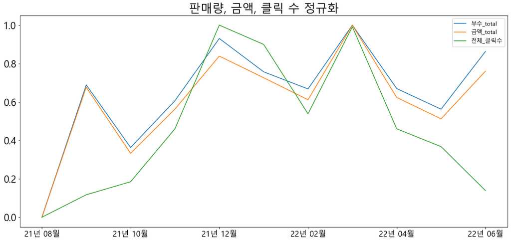

```python
fig = plt.figure(figsize=(18, 8))
ax = plt.subplot(1,1,1)

corr_df.apply(min_max).plot(ax = ax)
plt.title('판매량, 금액, 클릭 수 정규화')

plt.xlabel('')
```

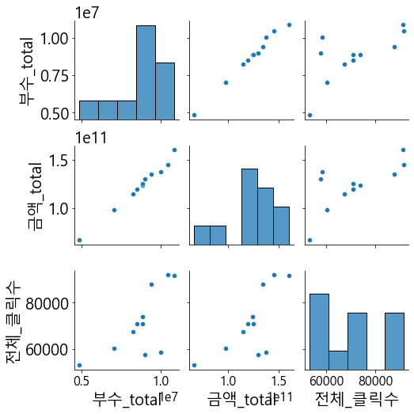

```python
import seaborn as sns
sns.pairplot(corr_df)
```

결론

- 도서 분야에서 전체 클릭 수가 높은 경우는 판매 지표도 높은 결과를 보였다.
- 하지만 클릭 수가 낮은 경우에도 높은 판매 지표를 보이기도 한다.
- 이는 클릭 수가 높으면 판매 량도 높지만, 반드시 클릭 수가 많아야 판매량이 높은것이 아님을 의미한다.
- 즉, 네이버 쇼핑에서의 클릭 수가 도서 구매 수에 대해 필요조건이 아닌 충분조건이라는 의미이다.